# Intro to ggplot2

# Layering geoms

Where ggplot2 becomes very powerful is that it allows you to layer geoms. Here we’re looking at a smoothed version of the data over all coordinates using loess smoothing.

```
## geom_smooth: method="auto" and size of largest group is <1000, so using loess. Use 'method = x' to change the smoothing method.
```

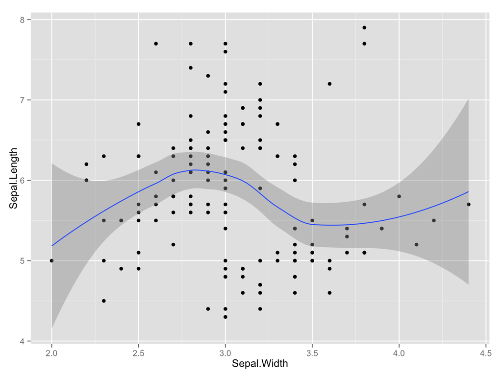

```r
ggplot(iris) + geom_point(aes(x= Sepal.Width, y=Sepal.Length)) +
  geom_smooth(aes(x= Sepal.Width, y=Sepal.Length))
```

# Facets - Subsetting the data

Perhaps we want to visualize the data onto three separate plots (one for each species). We can do this with facets:

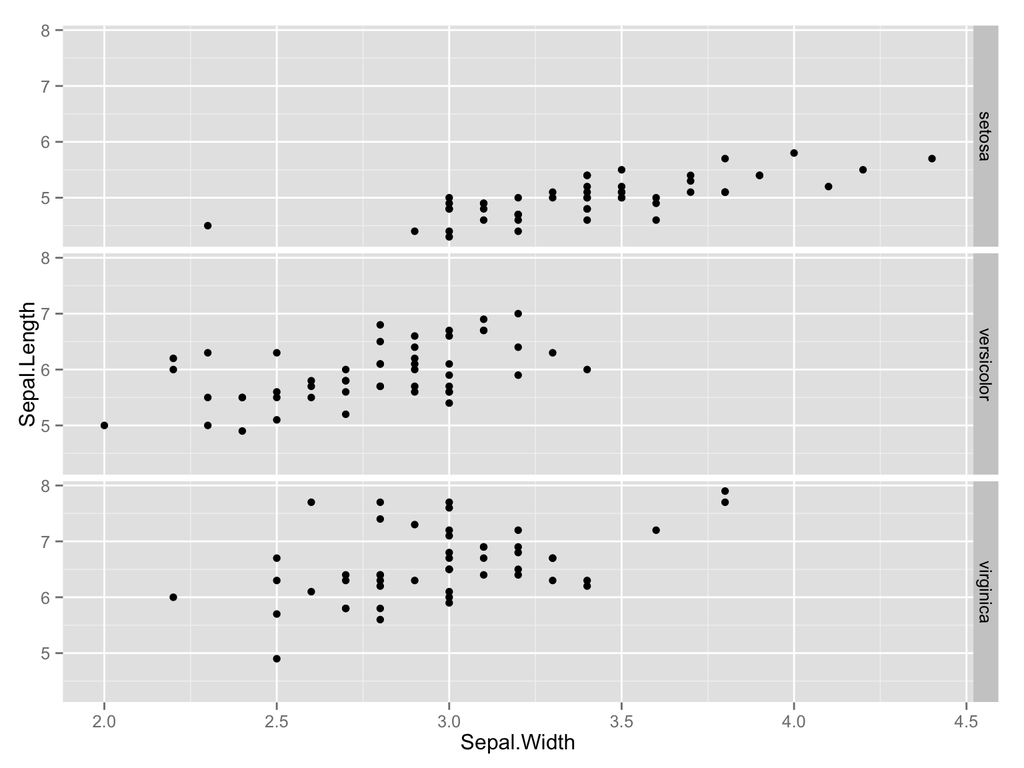

```r
ggplot(iris) + geom_point(aes(x= Sepal.Width, y=Sepal.Length)) +
  facet_grid(facets=Species ~ .)
```

```r
ggplot(iris) + geom_point(aes(x= Sepal.Width, y=Sepal.Length)) +
  facet_grid(facets=. ~ Species)
```

[output not shown]

# Theme properties and scaling

The look of everything on the graph can be customized, including

- color scale (continuous or discrete colors)
- order of elements
- fonts of everything
- labels and legends

See ?theme for more information. Also: http://sharpstatistics.co.uk/r/ggplot2-guide/

# Theme properties

The default theme is called theme_grey(). You can see all of the properties of a theme by looking at it.

```r
theme_grey()
```

```
## List of 40
##  $ line                :List of 4
##   ..$ colour  : chr "black"
##   ..$ size    : num 0.5
##   ..$ linetype: num 1
##   ..$ lineend : chr "butt"
##   ..- attr(*, "class")= chr [1:2] "element_line" "element"
##  $ rect                :List of 4
##   ..$ fill    : chr "white"
##   ..$ colour  : chr "black"
##   ..$ size    : num 0.5
##   ..$ linetype: num 1
##   ..- attr(*, "class")= chr [1:2] "element_rect" "element"
##  $ text                :List of 8
##   ..$ family    : chr ""
##   ..$ face      : chr "plain"
##   ..$ colour    : chr "black"
##   ..$ size      : num 12
##   ..$ hjust     : num 0.5
##   ..$ vjust     : num 0.5
##   ..$ angle     : num 0
##   ..$ lineheight: num 0.9
##   ..- attr(*, "class")= chr [1:2] "element_text" "element"
##  $ axis.text           :List of 8
##   ..$ family    : NULL
##   ..$ face      : NULL
##   ..$ colour    : chr "grey50"
##   ..$ size      :Class 'rel'  num 0.8
##   ..$ hjust     : NULL
##   ..$ vjust     : NULL
##   ..$ angle     : NULL
##   ..$ lineheight: NULL
##   ..- attr(*, "class")= chr [1:2] "element_text" "element"
##  $ strip.text          :List of 8
##   ..$ family    : NULL
##   ..$ face      : NULL
##   ..$ colour    : NULL
##   ..$ size      :Class 'rel'  num 0.8
##   ..$ hjust     : NULL
##   ..$ vjust     : NULL
```

[output cut: 160 more lines]

```
##  $ plot.title          :List of 8
##   ..$ family    : NULL
##   ..$ face      : NULL
##   ..$ colour    : NULL
##   ..$ size      :Class 'rel'  num 1.2
##   ..$ hjust     : NULL
##   ..$ vjust     : NULL
##   ..$ angle     : NULL
##   ..$ lineheight: NULL
##   ..- attr(*, "class")= chr [1:2] "element_text" "element"
##  $ plot.margin         :Class 'unit'  atomic [1:4] 1 1 0.5 0.5
##   .. ..- attr(*, "unit")= chr "lines"
##   .. ..- attr(*, "valid.unit")= int 3
##  - attr(*, "class")= chr [1:2] "theme" "gg"
##  - attr(*, "complete")= logi TRUE
```

# Making a new theme

To customize the theme, you must use elements to fill out the various properties of the theme list. Each of these properties maps to a specific element, either element_text, element_rect, or element_line.

For example, we want a white background and different fonts for the axis titles.

```r
theme_new <- theme(panel.background = element_rect(fill = "white"),
                   axis.title.x = element_text(family = "Times New Roman"),
                   axis.title.y = element_text(family = "Arial"))
```

# Trying our new theme out

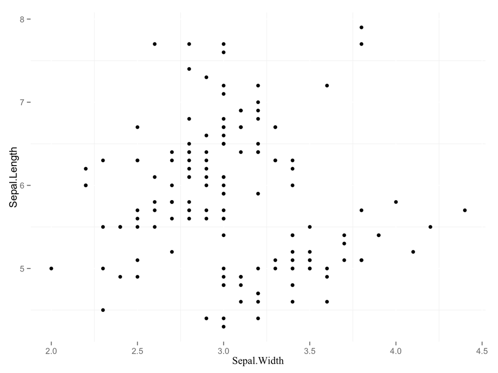

```r
ggplot(iris) + geom_point(aes(x= Sepal.Width, y=Sepal.Length)) + theme_new
```

# Changing a discrete color scale

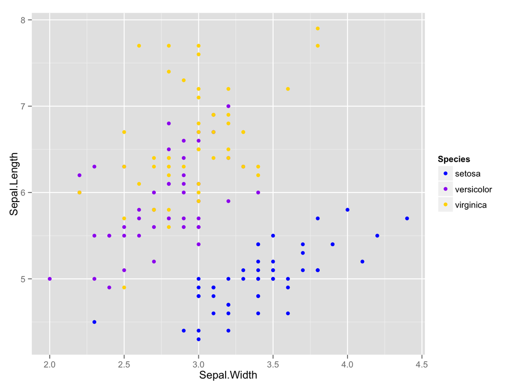

```r
ggplot(iris) + geom_point(aes(x= Sepal.Width, y=Sepal.Length, color=Species)) +
  scale_color_manual(values= c("blue", "purple", "gold"))
```

# If your data is originally in a matrix like format

For bioinformaticians, we often work with a matrix like format where genes are rows and samples are columns. This “wide” data format is not really usable by ggplot.

We need to “melt” the data frame to make it easier for ggplot to work with. Our melted data frame will have one data point for row, and additional Gene and Sample Columns. First we load our data in.

```r
library(reshape2)
expData <- data.frame(
  Gene = c("G1","G2","G3","G4", "G5", "G6", "G7", "G8"),
  Tumor1 = c( 5.6, 6.2, 5.6, 6.6, 1.3, 1.4, 2.1, 2.3),
  Tumor2 = c(5.4, 6.1, 5.8, 6.2, 1.3, 1.8, 2.2, 2.1),
  Normal1 = c(2.0, 2.5, 1.1, 2.8, 5.5, 5.8, 6.1, 5.7),
  Normal2 = c(2.1, 2.6, 1.3, 2.4, 5.7, 5.4, 5.8, 5.9)
)
expData
```

```
##   Gene Tumor1 Tumor2 Normal1 Normal2
## 1   G1    5.6    5.4     2.0     2.1
## 2   G2    6.2    6.1     2.5     2.6
## 3   G3    5.6    5.8     1.1     1.3
## 4   G4    6.6    6.2     2.8     2.4
## 5   G5    1.3    1.3     5.5     5.7
## 6   G6    1.4    1.8     5.8     5.4
## 7   G7    2.1    2.2     6.1     5.8
## 8   G8    2.3    2.1     5.7     5.9
```

# Melting the data into longform data

Then we melt the data using the melt() function:

```r
expDataMelt <- melt(expData, id.vars="Gene", variable.name="Sample",
                    value.name = "value")
expDataMelt
```

```
##    Gene  Sample value
## 1    G1  Tumor1   5.6
## 2    G2  Tumor1   6.2
## 3    G3  Tumor1   5.6
## 4    G4  Tumor1   6.6
## 5    G5  Tumor1   1.3
## 6    G6  Tumor1   1.4
## 7    G7  Tumor1   2.1
## 8    G8  Tumor1   2.3
## 9    G1  Tumor2   5.4
## 10   G2  Tumor2   6.1
## 11   G3  Tumor2   5.8
## 12   G4  Tumor2   6.2
## 13   G5  Tumor2   1.3
## 14   G6  Tumor2   1.8
```

[output cut: 18 more lines]

# Making a heatmap with our melted data

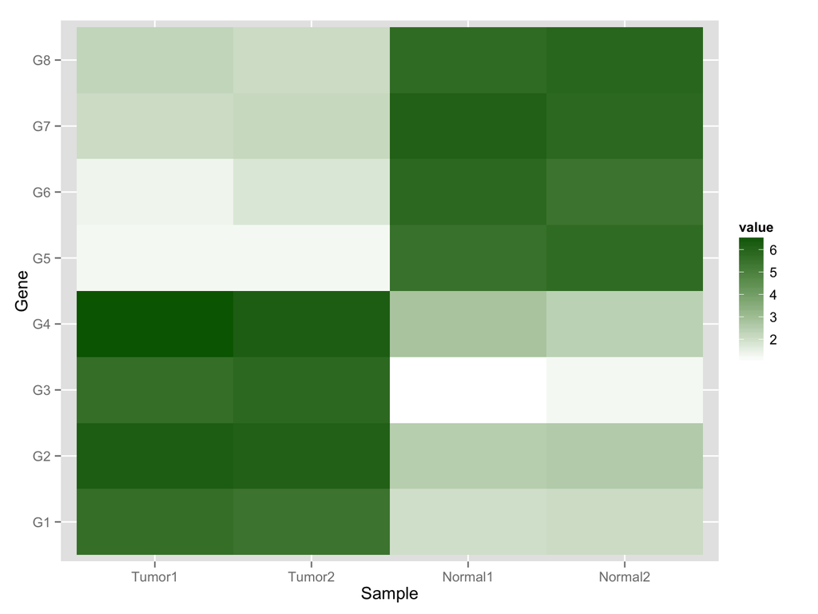

```r
ggplot(expDataMelt) + geom_tile(aes(x=Sample, y=Gene, fill=value)) +
scale_fill_gradient(low="white", high = "darkgreen")
```

# Using the built in Interface to ColorBrewer

Try different palette numbers here!

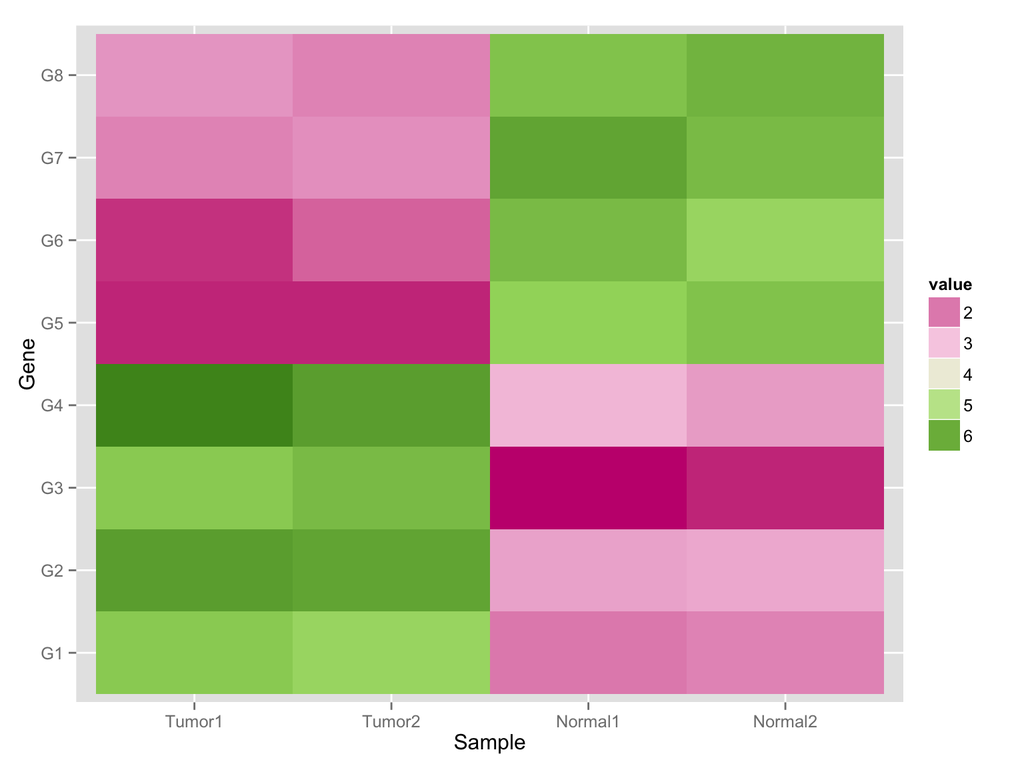

```r
ggplot(expDataMelt) + geom_tile(aes(x=Sample, y=Gene, fill=value)) +
 scale_fill_distiller(type="div", palette = 2)
```

# Rotating labels and prettifying

You can change labels using the labs() function and you can also use one theme as a starting point and modify it as you wish.

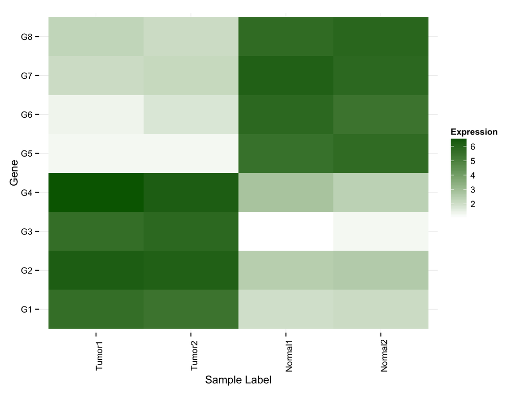

```r
ggplot(expDataMelt) + geom_tile(aes(x=Sample, y=Gene, fill=value)) +
  scale_fill_gradient(low="white", high = "darkgreen") +
  labs(x= "Sample Label", fill="Expression") +
  theme_minimal() +
  theme(axis.text.x = element_text(angle=90))
```

# Making a line plot with our melted data

Let’s plot the expression values as a line plot. To do this we need to tell ggplot2 that we want to plot each line by gene group. Additionaly we want a facet for each gene.

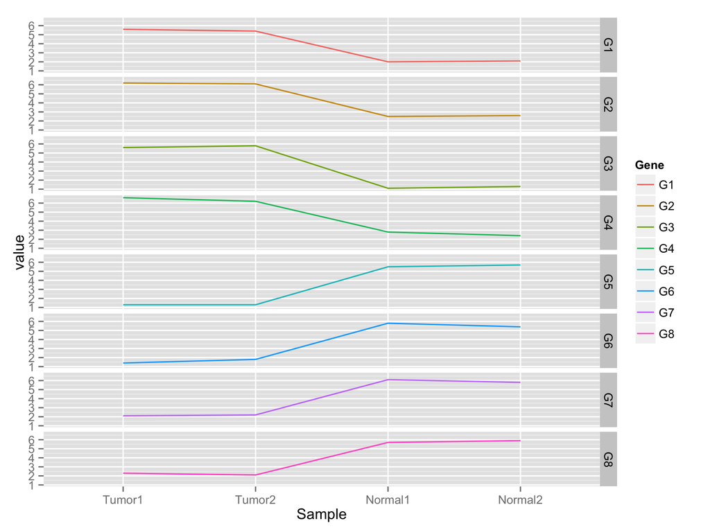

```r
ggplot(expDataMelt) + geom_line(aes(x=Sample, y=value, color=Gene, group=Gene)) +
  facet_grid(facets= Gene ~.)
```

# A More Complex Example

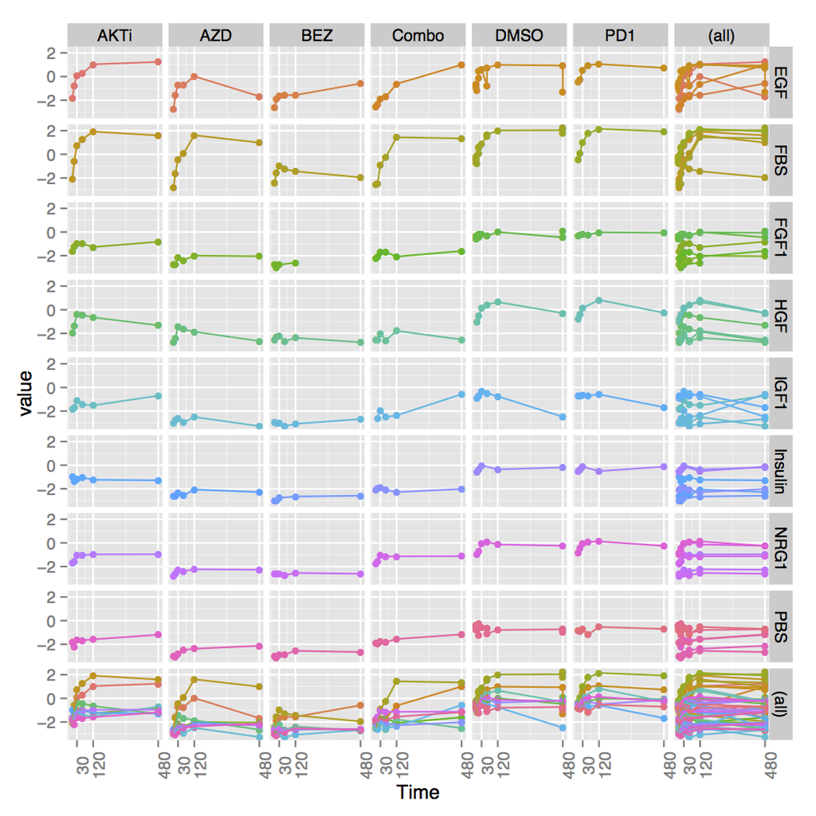

```r
ggplot(drugmelt[drugmelt$variable == "S6_pS235_S236" & !is.na(drugmelt$Stim) &
                  drugmelt$Cell == "BT20" & !drugmelt$Drug %in% c("DAS", "MEKi") &
                  drugmelt$Time < 720,], aes(Time, value, group=DS, colour=DS)) +
    geom_point() + geom_line() + facet_grid(Stim ~ Drug, margin=T) +
  scale_x_continuous(breaks = c(30, 120, 480, 720)) +
  theme(legend.position = "none", axis.text.x = element_text(angle=90))
```

# Interactive plots with ggvis

ggplot2 is great for static graphics. But for interactive graphics that allow you to change parameters, you will need to learn ggvis.

The good news: ggvis uses a similar grammar. The bad news: everything has a different name. Learning how to parametrize a plot can be tricky.

# Thanks!

- Hadley Wickham for ggplot2 and ggvis
- Eric Leung for showing us knitR/Sweave

This presentation is available here: http://bit.ly/1GJu8GV

[figure not shown]

# Future Topics?

- Faculty Research Map
- OHSU Graduates in the real world